# STAT 420: Homework 04

Fall 2020, D. Unger

Due: Tuesday, October 6 by 11:30 PM CT

# Assignment

## Exercise 1 (Using `lm` for Inference)

For this exercise we will again use the `faithful` dataset. Remember, this is a default dataset in `R`, so there is no need to load it. You should use `?faithful` to refresh your memory about the background of this dataset about the duration and waiting times of eruptions of [the Old Faithful geyser](http://www.yellowstonepark.com/about-old-faithful/) in [Yellowstone National Park](https://en.wikipedia.org/wiki/Yellowstone_National_Park).

**(a)** Fit the following simple linear regression model in `R`. Use the eruption duration as the response and waiting time as the predictor.

$$Y_i = \beta_0 + \beta_1 x_i + \epsilon_i$$

Store the results in a variable called `faithful_model`. Use a $t$ test to test the significance of the regression. Report the following:

- The null and alternative hypotheses
- The value of the test statistic
- The p-value of the test
- A statistical decision at $\alpha = 0.01$
- A conclusion in the context of the problem

When reporting these, you should explicitly state them in your document, not assume that a reader will find and interpret them from a large block of `R` output.

```r
data(faithful)
faithful_model <- lm(eruptions~waiting,data=faithful)
faithful_coefficients <- summary(faithful_model)$coefficients
faithful_coefficients
```

```
##                Estimate  Std. Error   t value      Pr(>|t|)
## (Intercept) -1.87401599 0.160143302 -11.70212  7.359171e-26
## waiting      0.07562795 0.002218541  34.08904 8.129959e-100
```

Null hypothesis: There is not a significant linear relationship between waiting time and eruption time. ($\beta_1 = 0$)

Alternative hypothesis: There is a significant linear relationship between waiting time and eruption time. ($\beta_1 != 0$)

Test Statistic: $\beta_1$:

```r
faithful_coefficients[2,3]
```

```
## [1] 34.08904
```

P-value:

```r
faithful_coefficients[2,4]
```

```
## [1] 8.129959e-100
```

Statistical Decision: Reject null hypothesis at α = 0.01 level.

There is a statistically significant linear relationship between waiting time and eruption time.

**(b)** Calculate a 99% confidence interval for $\beta_1$. Give an interpretation of the interval in the context of the problem.

```r
confint(faithful_model,level=0.99)
```

```
##                  0.5 %     99.5 %
## (Intercept) -2.2894534 -1.4585785
## waiting      0.0698727  0.0813832
```

**(c)** Calculate a 90% confidence interval for $\beta_0$. Give an interpretation of the interval in the context of the problem.

```r
confint(faithful_model,level=0.90)
```

```
##                     5 %        95 %
## (Intercept) -2.13833519 -1.60969678
## waiting      0.07196621  0.07928969
```

We are 90% sure that for a waiting time of 0 minutes, the average eruption duration will be between -2.13833519 and -1.60969678. However, this interval does not make logical sense as an eruption cannot last for negative minutes and a waiting time of 0 minutes means it is essentially the same eruption.

**(d)** Use a 95% confidence interval to estimate the mean eruption duration for waiting times of 75 and 80 minutes. Which of the two intervals is wider? Why?

```r
new_waitingtimes <- data.frame(waiting = c(75,80))
CInew <- predict(faithful_model,newdata=new_waitingtimes,interval=c("confidence"),level=0.95)
CInew
```

```
##       fit      lwr      upr
## 1 3.79808 3.736159 3.860002
## 2 4.17622 4.104848 4.247592
```

```r
diff(CInew[1,2:3])
```

```
##       upr
## 0.1238428
```

```r
diff(CInew[2,2:3])
```

```
##       upr
## 0.1427442
```

The range for the 80 minute waiting time is wider because as waiting time increases, we are less confident about our model.

**(e)** Use a 95% prediction interval to predict the eruption duration for waiting times of 75 and 100 minutes.

```r
new_waitingtimes2 <- data.frame(waiting = c(75,100))
CInew2 <- predict(faithful_model,newdata=new_waitingtimes2,interval=c("prediction"),level=0.95)
CInew2
```

```
##        fit      lwr      upr
## 1 3.798080 2.818592 4.777569
## 2 5.688779 4.701239 6.676319
```

**(f)** Create a scatterplot of the data. Add the regression line, 95% confidence bands, and 95% prediction bands.

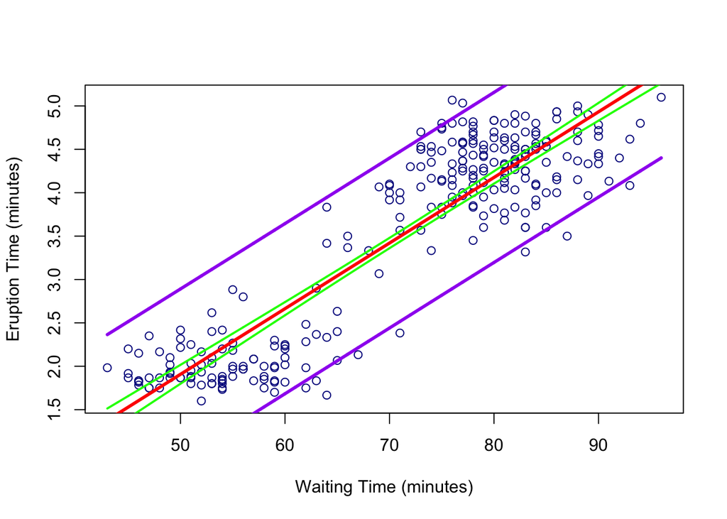

```r
grid <- seq(min(faithful$waiting),max(faithful$waiting), by=0.01)
eruptions_ci_band <- predict(faithful_model,newdata=data.frame(waiting=grid),interval = "confidence", level=0.95)
eruptions_pi_band <- predict(faithful_model,newdata=data.frame(waiting=grid),interval = "prediction", level=0.95)

plot(eruptions~waiting, data=faithful,
     xlab = "Waiting Time (minutes)",
     ylab = "Eruption Time (minutes)",
     col = "darkblue")
abline(faithful_model,lwd=3,col="red")

lines(grid, eruptions_ci_band[,"lwr"],col="green", lwd = 2)
lines(grid, eruptions_ci_band[,"upr"],col="green", lwd = 2)
lines(grid, eruptions_pi_band[,"lwr"],col="purple", lwd=3)
lines(grid, eruptions_pi_band[,"upr"],col="purple", lwd=3)
```

## Exercise 2 (Using `lm` for Inference)

For this exercise we will again use the `diabetes` dataset, which can be found in the `faraway` package.

**(a)** Fit the following simple linear regression model in `R`. Use the total cholesterol as the response and weight as the predictor.

$$Y_i = \beta_0 + \beta_1 x_i + \epsilon_i$$

Store the results in a variable called `cholesterol_model`. Use an $F$ test to test the significance of the regression. Report the following:

- The null and alternative hypotheses
- The ANOVA table (You may use `anova()` and omit the row for Total.)
- The value of the test statistic
- The p-value of the test
- A statistical decision at $\alpha = 0.05$
- A conclusion in the context of the problem

When reporting these, you should explicitly state them in your document, not assume that a reader will find and interpret them from a large block of `R` output.

```r
library(faraway)
data(diabetes)
cholesterol_model <- lm(chol~weight,data=diabetes)
summary(cholesterol_model)
```

```
##
## Call:
## lm(formula = chol ~ weight, data = diabetes)
##
## Residuals:
##     Min      1Q  Median      3Q     Max
## -125.75  -29.50   -3.24   22.62  230.71
##
## Coefficients:
##              Estimate Std. Error t value Pr(>|t|)
## (Intercept) 194.98642   10.02215  19.456   <2e-16 ***
## weight        0.07363    0.05499   1.339    0.181
## ---
## Signif. codes:  0 '***' 0.001 '**' 0.01 '*' 0.05 '.' 0.1 ' ' 1
##
## Residual standard error: 44.21 on 399 degrees of freedom
##   (2 observations deleted due to missingness)
## Multiple R-squared:  0.004474,   Adjusted R-squared:  0.001979
## F-statistic: 1.793 on 1 and 399 DF,  p-value: 0.1813
```

ANOVA Table:

```r
anovatest = anova(cholesterol_model)
anovatest["weight",]
```

```
## Analysis of Variance Table
##
## Response: chol
##        Df Sum Sq Mean Sq F value Pr(>F)
## weight  1 3505.4  3505.4  1.7932 0.1813
```

Null hypothesis: There is not a significant linear relationship between weight and total cholesterol. ($\beta_1 = 0$)

Alternative hypothesis: There is a significant linear relationship between weight and total cholesterol. ($\beta_1 != 0$)

Test Statistic: $\beta_1$:

```r
anovatest[1,4]
```

```
## [1] 1.793178
```

P-value:

```r
anovatest[1,5]
```

```
## [1] 0.1813018
```

Statistical Decision: Fail to reject the null hypothesis at α = 0.05 level.

There is not a statistically significant linear relationship between weight and total cholesterol.

**(b)** Fit the following simple linear regression model in `R`. Use HDL as the response and weight as the predictor.

$$Y_i = \beta_0 + \beta_1 x_i + \epsilon_i$$

Store the results in a variable called `hdl_model`. Use an $F$ test to test the significance of the regression. Report the following:

- The null and alternative hypotheses
- The ANOVA table (You may use `anova()` and omit the row for Total.)
- The value of the test statistic
- The p-value of the test
- A statistical decision at $\alpha = 0.05$
- A conclusion in the context of the problem

When reporting these, you should explicitly state them in your document, not assume that a reader will find and interpret them from a large block of `R` output.

```r
hdl_model <- lm(hdl~weight,data=diabetes)
summary(hdl_model)
```

```
##
## Call:
## lm(formula = hdl ~ weight, data = diabetes)
##
## Residuals:
##     Min      1Q  Median      3Q     Max
## -45.829 -10.455  -3.330   8.421  69.670
##
## Coefficients:
##             Estimate Std. Error t value Pr(>|t|)
## (Intercept) 72.70233    3.74976  19.389  < 2e-16 ***
## weight      -0.12499    0.02057  -6.075 2.89e-09 ***
## ---
## Signif. codes:  0 '***' 0.001 '**' 0.01 '*' 0.05 '.' 0.1 ' ' 1
##
## Residual standard error: 16.54 on 399 degrees of freedom
##   (2 observations deleted due to missingness)
## Multiple R-squared:  0.08467,    Adjusted R-squared:  0.08238
## F-statistic: 36.91 on 1 and 399 DF,  p-value: 2.891e-09
```

ANOVA Table:

```r
anovatest2 = anova(hdl_model)
anovatest2["weight",]
```

```
## Analysis of Variance Table
##
## Response: hdl
##        Df Sum Sq Mean Sq F value    Pr(>F)
## weight  1  10100   10100  36.909 2.891e-09 ***
## ---
## Signif. codes:  0 '***' 0.001 '**' 0.01 '*' 0.05 '.' 0.1 ' ' 1
```

Null hypothesis: There is not a significant linear relationship between weight and High-Density Lipoprotein. ($\beta_1 = 0$)

Alternative hypothesis: There is a significant linear relationship between weight and High-Density Lipoprotein. ($\beta_1 != 0$)

Test Statistic: $\beta_1$:

```r
anovatest2[1,4]
```

```
## [1] 36.90875
```

P-value:

```r
anovatest2[1,5]
```

```
## [1] 2.890526e-09
```

Statistical Decision: Reject the null hypothesis at α = 0.05 level.

There is a statistically significant linear relationship between weight and high-density lipoprotein.

## Exercise 3 (Inference “without” `lm`)

For this exercise we will once again use the data stored in `goalies.csv`. It contains career data for all 716 players in the history of the National Hockey League to play goaltender through the 2014-2015 season. The two variables we are interested in are:

- `W` - Wins
- `MIN` - Minutes

Fit a SLR model with `W` as the response and `MIN` as the predictor. Test $H_0: \beta_1 = 0.008$ vs $H_1: \beta_1 < 0.008$ at $\alpha = 0.01$. Report the following:

- $\hat{\beta_1}$
- $SE[\hat{\beta_1}]$
- The value of the $t$ test statistic
- The degrees of freedom
- The p-value of the test
- A statistical decision at $\alpha = 0.01$

When reporting these, you should explicitly state them in your document, not assume that a reader will find and interpret them from a large block of `R` output.

You should use `lm()` to fit the model and obtain the estimate and standard error. But then you should directly calculate the remaining values. Hint: be careful with the degrees of freedom. Think about how many observations are being used.

```r
goalies <- read.csv("goalies.csv")
goalies_model <- lm(W~MIN,data=goalies)
coefficients <- summary(goalies_model)$coefficients
coefficients
```

```
##                 Estimate   Std. Error    t value     Pr(>|t|)
## (Intercept) -4.402376990 7.697896e-01  -5.718936 1.578764e-08
## MIN          0.007845997 5.070963e-05 154.724008 0.000000e+00
```

```r
est  = coefficients[2,1]
hyp  = 0.008
se   = coefficients[2,2]
df   = length(resid(goalies_model))-2
t    = (est - hyp) / se
pval = pt(t, df = df)
est
```

```
## [1] 0.007845997
```

```r
se
```

```
## [1] 5.070963e-05
```

```r
t
```

```
## [1] -3.036956
```

```r
df
```

```
## [1] 711
```

```r
pval
```

```
## [1] 0.0012386
```

$\hat{\beta_1}$: 0.007845997

$SE[\hat{\beta_1}]$:5.070963e-05

Test Statistic(t): -3.036956

Degrees of Freedom: 711

P-value: 0.0012386

Since the p-value is less than the alpha value of 0.01, we reject the null hypothesis.

## Exercise 4 (Simulating Sampling Distributions)

For this exercise we will simulate data from the following model:

$$Y_i = \beta_0 + \beta_1 x_i + \epsilon_i$$

Where $\epsilon_i \sim N(0, \sigma^2).$ Also, the parameters are known to be:

- $\beta_0 = 4$
- $\beta_1 = 0.5$
- $\sigma^2 = 25$

We will use samples of size $n = 50$.

**(a)** Simulate this model $1500$ times. Each time use `lm()` to fit a SLR model, then store the value of $\hat{\beta}_0$ and $\hat{\beta}_1$. Set a seed using **your** UIN before performing the simulation. Note, we are simulating the $x$ values once, and then they remain fixed for the remainder of the exercise.

```r
uin = 662540538
set.seed(uin)
n = 50
x = seq(0, 20, length = n)
```

```r
beta_0 = 4
beta_1 = 0.5
sigma=5

num_samples = 1500
beta_0_hats = rep(0, num_samples)
beta_1_hats = rep(0, num_samples)

for (i in 1:num_samples) {
  eps = rnorm(n, mean = 0, sd = sigma)
  y   = beta_0 + beta_1 * x + eps

  sim_model = lm(y ~ x)

  beta_0_hats[i] = coef(sim_model)[1]
  beta_1_hats[i] = coef(sim_model)[2]
}
```

**(b)** For the *known* values of $x$, what is the expected value of $\hat{\beta}_1$?

```r
beta_1
```

```
## [1] 0.5
```

**(c)** For the known values of $x$, what is the standard deviation of $\hat{\beta}_1$?

```r
Sxx = sum((x-mean(x))^2)
sd = sigma / sqrt(Sxx)
sd
```

```
## [1] 0.120049
```

**(d)** What is the mean of your simulated values of $\hat{\beta}_1$? Does this make sense given your answer in **(b)**?

```r
mean(beta_1_hats)
```

```
## [1] 0.50065
```

This is very close to the true mean of 0.5, so yes it does make sense.

**(e)** What is the standard deviation of your simulated values of $\hat{\beta}_1$? Does this make sense given your answer in **(c)**?

```r
sd(beta_1_hats)
```

```
## [1] 0.1194811
```

**(f)** For the known values of $x$, what is the expected value of $\hat{\beta}_0$?

```r
beta_0
```

```
## [1] 4
```

**(g)** For the known values of $x$, what is the standard deviation of $\hat{\beta}_0$?

```r
sigma * sqrt(1/n + mean(x)^2/Sxx)
```

```
## [1] 1.393261
```

**(h)** What is the mean of your simulated values of $\hat{\beta}_0$? Does this make sense given your answer in **(f)**?

```r
mean(beta_0_hats)
```

```
## [1] 3.984769
```

Yes, it makes sense since it is very close to beta_0 from x.

**(i)** What is the standard deviation of your simulated values of $\hat{\beta}_0$? Does this make sense given your answer in **(g)**?

```r
sd(beta_0_hats)
```

```
## [1] 1.380591
```

Yes, since this is close to the true standard deviation of x.

**(j)** Plot a histogram of your simulated values for $\hat{\beta}_1$. Add the normal curve for the true sampling distribution of $\hat{\beta}_1$.

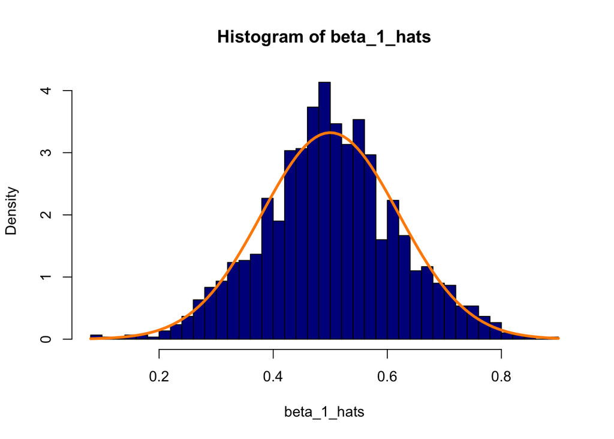

```r
hist(beta_1_hats, breaks=30,col="darkblue", prob=TRUE)
curve(dnorm(x, mean = beta_1, sd = sigma / sqrt(Sxx)),
      col = "darkorange", add = TRUE, lwd = 3)
```

**(k)** Plot a histogram of your simulated values for $\hat{\beta}_0$. Add the normal curve for the true sampling distribution of $\hat{\beta}_0$.

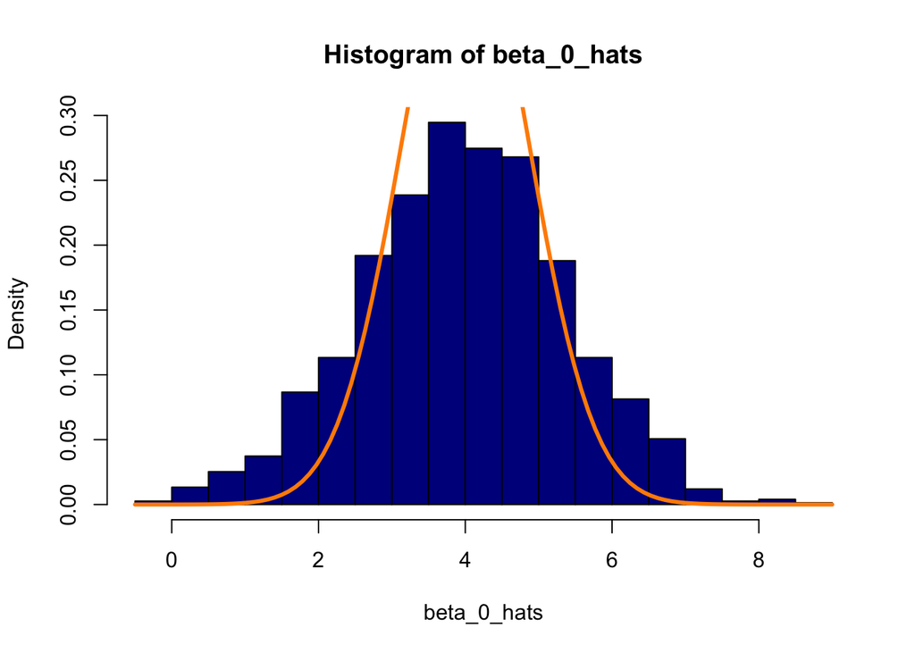

```r
hist(beta_0_hats, breaks=30,col="darkblue", prob=TRUE)
curve(dnorm(x, mean = beta_0, sd = sigma * sqrt(1/n + mean(x)^2/Sxx)),
      col = "darkorange", add = TRUE, lwd = 3)
```

## Exercise 5 (Simulating Confidence Intervals)

For this exercise we will simulate data from the following model:

$$Y_i = \beta_0 + \beta_1 x_i + \epsilon_i$$

Where $\epsilon_i \sim N(0, \sigma^2).$ Also, the parameters are known to be:

- $\beta_0 = 1$
- $\beta_1 = 3$
- $\sigma^2 = 16$

We will use samples of size $n = 20$.

Our goal here is to use simulation to verify that the confidence intervals really do have their stated confidence level.

**(a)** Simulate this model $2000$ times. Each time use `lm()` to fit a SLR model, then store the value of $\hat{\beta}_0$ and $s_e$. Set a seed using **your** UIN before performing the simulation. Note, we are simulating the $x$ values once, and then they remain fixed for the remainder of the exercise.

```r
uin = 662540538
set.seed(uin)
n = 20
x = seq(-5, 5, length = n)
```

```r
beta_0=1
beta_1=3
sigma = 4

num_samples = 2000
beta_0_hats = rep(0, num_samples)
se_hats = rep(0, num_samples)

for (i in 1:num_samples) {
  eps = rnorm(n, mean = 0, sd = sigma)
  y   = beta_0 + beta_1 * x + eps

  sim_model = lm(y ~ x)

  beta_0_hats[i] = coef(sim_model)[1]
  se_hats[i] = summary(sim_model)$sigma
}
```

**(b)** For each of the $\hat{\beta}_0$ that you simulated calculate a 90% confidence interval. Store the lower limits in a vector `lower_90` and the upper limits in a vector `upper_90`. Some hints:

- You will need to use `qt()` to calculate the critical value, which will be the same for each interval.
- Remember that `x` is fixed, so $S_{xx}$ will be the same for each interval.
- You could, but do not need to write a `for` loop. Remember vectorized operations.

```r
alpha = 0.10
tcrit = -qt(alpha/2,df=n-2)
Sxx= sum((x-mean(x))^2)

lower_90 = beta_0_hats - tcrit*se_hats * sqrt(1/n + mean(x)^2/Sxx)
upper_90 = beta_0_hats + tcrit*se_hats * sqrt(1/n + mean(x)^2/Sxx)
```

**(c)** What proportion of these intervals contain the true value of $\beta_0$?

```r
mean(lower_90 <1 & upper_90 > 1)
```

```
## [1] 0.904
```

**(d)** Based on these intervals, what proportion of the simulations would reject the test $H_0: \beta_0 = 0$ vs $H_1: \beta_0 \neq 0$ at $\alpha = 0.10$?

```r
1 - mean(lower_90 <0 & upper_90 >0)
```

```
## [1] 0.2725
```

**(e)** For each of the $\hat{\beta}_0$ that you simulated calculate a 99% confidence interval. Store the lower limits in a vector `lower_99` and the upper limits in a vector `upper_99`.

```r
alpha = 0.01
tcrit = -qt(alpha/2,df=n-2)
Sxx= sum((x-mean(x))^2)

lower_99 = beta_0_hats - tcrit*se_hats * sqrt(1/n + mean(x)^2/Sxx)
upper_99 = beta_0_hats + tcrit*se_hats * sqrt(1/n + mean(x)^2/Sxx)
```

**(f)** What proportion of these intervals contain the true value of $\beta_0$?

```r
mean(lower_99 < 1 & upper_99 > 1)
```

```
## [1] 0.989
```

**(g)** Based on these intervals, what proportion of the simulations would reject the test $H_0: \beta_0 = 0$ vs $H_1: \beta_0 \neq 0$ at $\alpha = 0.01$?

```r
1 - mean(lower_99 <0 & upper_99 > 0)
```

```
## [1] 0.0615
```